# Workflow of scATAC-seq with multiome data

Maria Lucia Romero Rivero

MLROMEROR@clinic.cat

2022-11-15

# 1 Introduction

Hi to everyone! In this notebook we are going to practice how to analyse scATAC-se using multiome data (ATAC + GEX) by using the `Signac`( *Stuart et al.* , 2020) package. `Signac` ( *Stuart et al.* , 2020) in an extension of the very well-known `Seurat` package to analyse scATAC-seq data. We could say that is the successor to sequencing techniques like ChIP-seq and RRBS-Seq (a type of bisulfite sequencing).

# 2 Instalation

# 3 Load packages

```r
library(Signac)
library(Seurat)
library(ggplot2)
library(ggpubr)
library(tidyverse)
library(EnsDb.Hsapiens.v86)
library(plyr)
library(reshape2)
library(data.table)
library(GenomicRanges)
library(ensembldb)
library(hdf5r)
library(stringr)
library(ggpubr)
library(RColorBrewer)
library(magick)
library(knitr)
library(biovizBase)
library(kableExtra)
library(scater)
set.seed(123)
```

## 3.1 Directory path

```r
# Paths
path_exp<-here::here("data/Experiment/1")
path_to_save <- here::here("results/R_objects/")
path_to_save_tables <- here::here("results/tables/")
```

## 3.2 Histogram function

```r
plot_histogram_qc <- function(df, x, x_lab) {
  df %>%
    ggplot(aes_string(x)) +
    geom_histogram(bins = 100) +
    labs(x = x_lab, y = "Number of Cells") +
    theme_pubr()
}
```

## 3.3 Gene annotation

Extraction of gene annotations from EnsDb using hg38 as the reference assembly.

```r
annotation <- GetGRangesFromEnsDb(ensdb = EnsDb.Hsapiens.v86)
seqlevelsStyle(annotation) <- "UCSC"
genome(annotation) <- "hg38"
```

# 4 Loading data and preprocessing

`Signac`and `Seurat` uses information from three related input files generate by the *CellRanger ARC*. If we were analysing multiome data, we should use both `Signac` to analyse scATAC-seq data and `Seurat` for scRNA-seq data but in this case we will jsut use `Seurat`package to create the Seurat Object of the GEX data. First, as we do in scRNA-seq, we will use the `Read10X()` function to read the output of the cellranger pipeline, returning: a unique molecular identified (UMI)/Peak count matrix and a fragment file.

- 1 *Count matrix in h5 format Peak/UMI matrix*: This is analogous to the gene expression count matrix used to analyze single-cell RNA-seq. However, instead of genes, each row of the matrix represents a region of the genome (a peak), that is predicted to represent a region of open chromatin. Each value in the matrix represents the number of Tn5 integration sites for each single barcode (i.e. a cell) that map within each peak. You can find more detail on the 10X Website.
- 2. ATAC Fragment file (atac_fragments.tsv.gz)
- 3. ATAC Fragment file index (atac_fragments.tsv.gz.tbi)
- *Fragment file* : it represents a full list of all unique fragments across all single cells. It is a substantially larger file, is slower to work with. It contains all fragments associated with each single cell, as opposed to only fragments that map to peaks. Signac uses information from three related input files (created using CellRanger ARC):

## 4.1 Visualisation of the files

```r
# We load the file and we visualise the 6 first rows of the matrix
count_matrix <- Read10X_h5(paste0(path_exp,"/co7dzuup_xuczw9vc/filtered_feature_bc_matrix.h5"))
```

The `count_matrix` has 2 matrices:

- *Peaks* for the ATAC data
- *`Gene Expression`* for RNA data

```r
count_matrix$Peaks[c(1:5), c(1:5)]
```

```
## 5 x 5 sparse Matrix of class "dgCMatrix"
##                    AAACAGCCAAAGGTAC-1 AAACAGCCAATAGCAA-1 AAACAGCCACGTAAGG-1
## chr1:180786-180941                  .                  .                  .
## chr1:629712-630835                  .                  .                  2
## chr1:633787-634272                  2                  .                  2
## chr1:775074-775469                  .                  .                  .
## chr1:778034-779715                  .                  .                  .
##                    AAACAGCCATTAAGTC-1 AAACATGCAAGCCAGA-1
## chr1:180786-180941                  .                  .
## chr1:629712-630835                  .                  .
## chr1:633787-634272                  .                  .
## chr1:775074-775469                  .                  .
## chr1:778034-779715                  2                  2
```

Now, we can see that we have 115988 features where we have the *chromosome which is separated by a “:”* and the *start and end of the read position by a “-”* and 5572 cells.

```r
count_matrix$Peaks
```

```
## 115988 x 5572 sparse Matrix of class "dgCMatrix"
```

[output not shown]

[output not shown]

[output cut: 3177 more lines]

[output not shown]

[output not shown]

[output not shown]

[output cut: 3171 more lines]

[output not shown]

```r
count_matrix$`Gene Expression`[c(1:5), c(1:5)]
```

```
## 5 x 5 sparse Matrix of class "dgCMatrix"
##             AAACAGCCAAAGGTAC-1 AAACAGCCAATAGCAA-1 AAACAGCCACGTAAGG-1
## MIR1302-2HG                  .                  .                  .
## FAM138A                      .                  .                  .
## OR4F5                        .                  .                  .
## AL627309.1                   .                  .                  .
## AL627309.3                   .                  .                  .
##             AAACAGCCATTAAGTC-1 AAACATGCAAGCCAGA-1
## MIR1302-2HG                  .                  .
## FAM138A                      .                  .
## OR4F5                        .                  .
## AL627309.1                   .                  .
## AL627309.3                   .                  .
```

# 5 Create a Seurat Object

## 5.1 Step by step

Create a `ChromatinAssay`` object from a count matrix or normalized data matrix. The expected format of the input matrix is features x cells. A set of genomic ranges must be supplied along with the matrix, with the length of the ranges equal to the number of rows in the matrix. If a set of genomic ranges are not supplied, they will be extracted from the row names of the matrix.

CreateChromatinAssay( counts, data, min.cells = 0, min.features = 0, max.cells = NULL, ranges = NULL, motifs = NULL, fragments = NULL, genome = NULL, annotation = NULL, bias = NULL, positionEnrichment = NULL, sep = c(“-”, “-”), validate.fragments = TRUE, verbose = TRUE, … )

`counts` Unnormalized data (raw counts)

`fragments` Path to a tabix-indexed *fragments file* for the data contained in the input matrix. If multiple fragment files are required, you can add additional Fragment object to the assay after it is created using the `CreateFragmentObject` and Fragments functions. Alternatively, a list of Fragment objects can be provided.

`genome` A Seqinfo object containing basic information about the genome used. Alternatively, the name of a UCSC genome can be provided and the sequence information will be downloaded from UCSC.

`annotation` A set of GRanges containing annotations for the genome used

`sep`: Separators to use for strings encoding genomic coordinates. First element is used to separate the chromosome from the coordinates, second element is used to separate the start from end coordinate. Only used if ranges is NULL. In this case we will use *“:”* which separates `chromosome:start position` and *“-”* which separates `start position-end position` as we see before in the peakc count matrix.

```r
#Fragment directory path
fragpath <-"data/Experiment/1/co7dzuup_xuczw9vc/atac_fragments.tsv.gz"

# we create a Seurat Object for GEX data (scRNA-seq)
tonsil<-CreateSeuratObject(counts = count_matrix$`Gene Expression`, assay = "RNA")

# We create a `ChromatinAssay` object for ATAC data (scATAC-seq), in order to create a Seurta object.
 # get gene annotations for hg38

  annotation <- GetGRangesFromEnsDb(ensdb = EnsDb.Hsapiens.v86)
```

[output not shown]

[output cut: 16 more lines]

[output not shown]

```r
  seqlevelsStyle(annotation) <- "UCSC"


tonsil[["ATAC"]] <- CreateChromatinAssay(
  counts = count_matrix$Peaks,
  sep = c(":", "-"),
  genome="hg38",
  fragments = fragpath,
  annotation = annotation
  )
```

```
## Computing hash
```

If we look at the tonsil object:

We have 2 assays: RNA and ATAC In ATAC assay we have 115988 features and 5572 cells as we saw before.

```r
tonsil@assays
```

```
## $RNA
## Assay data with 36601 features for 5572 cells
## First 10 features:
##  MIR1302-2HG, FAM138A, OR4F5, AL627309.1, AL627309.3, AL627309.2,
## AL627309.5, AL627309.4, AP006222.2, AL732372.1
##
## $ATAC
## ChromatinAssay data with 115988 features for 5572 cells
## Variable features: 0
## Genome: hg38
## Annotation present: TRUE
## Motifs present: FALSE
## Fragment files: 1
```

In the metadata we have the number of Count and the number of feature for both methodologies for each barecode.

```r
tonsil@meta.data
```

[output not shown]

[output cut: 11091 more lines]

[output not shown]

## 5.2 Functions to intinerat through out the folders

Here we are going to create a list of Seurat object of more than 1 tonsil samples. For that, I did some function to automatize the process.

## 5.3 Create count matrix and a fragment path lists

`make.matrix.path` function create a list of all the matrix directory path of each multiome sample data.

`make.fragpath` function creates a list of all the fragment directory path of each multiome sample data.

```r
#function that creates list of all matrix path of each sample (file h5)
make.matrix.path <- function(path){
  sample.path=list()

                sample.path <-list.files(path=path,
                      pattern="h5", recursive = T, full.names = TRUE)

                return(sample.path)

}

#function creates a list of all fragment path of each sample (file  .tsv.gz)
make.fragpath <- function(path){
  sample.path<-list()

                sample.path <-list.files(path=path,
                      pattern=".tsv.gz$", recursive = T, full.names = TRUE)

                return(sample.path)

}
```

## 5.4 Create a multiome Seurat Object list

In this function called `make.SeuratObject.list` we will create a list of multiome of seurat object with chromatin assay data. It has the 2 previous function nested.

`CreateChromatinAssay`:

```r
make.SeuratObject.list <- function(path){
  sample.name <-list()
  matrix.pathList <-list()
  tonsil_list <-list()
  fragpathList<-list()

  #create a list with all the matrix path of each sample
  matrix.pathList<- make.matrix.path(path)

  #create a list of all the fragment path
  fragpathList<- make.fragpath(path)

# save sample name
  sample.name<- sub(".*Experiment/.*\\/(.*)\\/filtered_feature_bc_matrix.h5","\\1", matrix.pathList, perl = TRUE )
  annotation <- GetGRangesFromEnsDb(ensdb = EnsDb.Hsapiens.v86)
  seqlevelsStyle(annotation) <- "UCSC"
  genome(annotation) <- "hg38"

  for (i in seq_along(matrix.pathList)){

                # Reading coutn matrix data
                  counts = Read10X_h5(filename=matrix.pathList[[i]])

                  #List ot Fragment directory path
                  fragpath <-fragpathList[[i]]

                # we create a Seurat Object for GEX data (scRNA-seq)
                  tonsil<-CreateSeuratObject(counts = counts$`Gene Expression`, assay = "RNA")

                  # We create a `ChromatinAssay` object for ATAC data (scATAC-seq), in order to create a Seurta object.
                   # get gene annotations for hg38
                  tonsil[["ATAC"]] <- CreateChromatinAssay(
                    counts = counts$Peaks,
                    sep = c(":", "-"),
                    genome="hg38",
                    fragments = fragpath,
                    annotation = annotation
                    )


      # list of all the Seurat Objects for each sample.

                  tonsil_list[[sample.name[i]]] = assign(sample.name[[i]], tonsil, envir=.GlobalEnv)
                                        }
  return(tonsil_list)
                        }
```

## 5.5 Read samples and assign them to a proper library name

**Reading 2 tonsil samples**

```r
SeuratObject.list<-make.SeuratObject.list(path_exp)
```

```r
SeuratObject.list
```

```
## $co7dzuup_xuczw9vc
## An object of class Seurat
## 152589 features across 5572 samples within 2 assays
## Active assay: RNA (36601 features, 0 variable features)
##  1 other assay present: ATAC
##
## $ulx1v6sz_8a2nvf1c
## An object of class Seurat
## 144601 features across 7181 samples within 2 assays
## Active assay: RNA (36601 features, 0 variable features)
##  1 other assay present: ATAC
```

`list.name` is a list of id sample with each library name.

```r
list.name<-list(
co7dzuup_xuczw9vc="BCLL_9_T_1" ,
ulx1v6sz_8a2nvf1c="BCLL_8_T_1" )

list.name<-list.name[order(names(list.name))]
```

### 5.5.1 Change sample names by library name

```r
#Change sample ID by library name.
names(SeuratObject.list)<- c(list.name[[1]],list.name[[2]])
```

# 6 Quality control

Quality control metrics are collected to determine library complexity, signal to noise ratios, fragment length distribution per replicate (where available), and reproducibility.

Here we will create a list called `quality_control` which has all the quality control of each Seurat object of each samples.

Look at the distributions before deciding on cutoffs.

## 6.1 Quality Ccontrol (QC) Function

This function will carry out the Nucleosome signal using `NucleosomeSignal`function, the TSS enrichment using `TSSEnrichment`function and also it will calculate the fraction of mitochondria and ribosomal RNA in each sample.

- Mitochondrial genes are useful indicators of cell state. High mitochondrial RNA fraction means that the cell are death, it has released the mitochondrial RNA.
- We can define ribosomal proteins (their names begin with RPS or RPL), which often take substantial fraction of reads:

```r
QC <- function(SeuratObject.list){


  DefaultAssay(SeuratObject.list) <- "ATAC"
  SeuratObject.list <- NucleosomeSignal(SeuratObject.list)
  SeuratObject.list <- TSSEnrichment(SeuratObject.list, fast = FALSE)
  SeuratObject.list$tss.level <- ifelse(SeuratObject.list$TSS.enrichment > 2, "High", "Low")

  DefaultAssay(SeuratObject.list)<-"RNA"
  SeuratObject.list[["percent_mt"]] <- PercentageFeatureSet(SeuratObject.list, pattern = "^MT-")
  SeuratObject.list[["percent_ribo"]] <- PercentageFeatureSet(SeuratObject.list, pattern = "^RP[SL]")

return(SeuratObject.list)

}
```

## 6.2 Calculating QC metrics

This quality control process will last around 496.867 sec (around 8-9 min), so you can go to get a coffe and streach your legs ;)

```r
quality_control = lapply(SeuratObject.list, QC)
```

## 6.3 Create a data frame of the metadata

After the QC process, we use this function to make a data frame with only the metadata of each library.

```r
md_df<- data.frame()
make.metadata.df<- function (quality_control){

  md_df = rbind(md_df, quality_control@meta.data)

  return(md_df)
}
```

We will create a data frame with only the metadata of each sample which will be called `metadata_df`.

```r
df<-lapply(quality_control, make.metadata.df)
##create a data frame of all metadata
metadata_df <- map_df(df, ~as.data.frame(.x), .id="id")
metadata_df<-metadata_df[order(metadata_df$id),]

write.csv(metadata_df, paste0(path_to_save_tables,"metadata_df_qc.csv"), row.names=TRUE, quote=FALSE)
```

## 6.4 Table with the initial number of cell of each sample

```r
num_cell<- as.data.frame(ddply(metadata_df, .(id), nrow))

#change column names
colnames(num_cell) <- c("library_name","initial_cells")
```

One important step is to know the exactly number of initial cells we have in each sample to know the percentage of cell we are going to keep after the filtering process.

Table 1: Table of total number of initial barcoded cell of each library

| library_name | Total Number initial_cells |
| --- | --- |
| BCLL_8_T_1 | 7181 |
| BCLL_9_T_1 | 5572 |

```r
print(paste0( "There are ", sum(num_cell$initial_cells), " total number of cells"))
```

```
## [1] "There are 12753 total number of cells"
```

## 6.5 Parameters

After analysing the quality control (QC) characteristics of each sample, here we set up the quality control metrics in order to perform the filtering of ATAC and RNA seq analysis.

```r
# Thresholds
# ATAC-seq
TSS_enrichment <- 2
nucleosome_signal_atac <- 2
min_lib_size_atac<- 300
max_lib_size_atac <- 200000


#RNA-seq
min_lib_size_rna<-470
max_lib_size_rna<-40000
min_ngenes_rna<-250
max_ngenes_rna<-7000
max_percent_mit <-20
```

## 6.6 scATAC parameters

### 6.6.1 Library sizes

The library size of ATAC-seq make reference to the number of reads of each fragment.

The red dashed lines represent the lower and the upper thresholds applied.

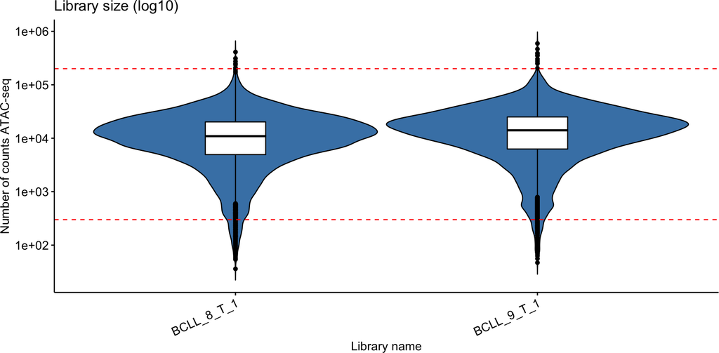

```r
ls2<- ggviolin(metadata_df,
              x = "id", fill = "steelblue", x.text.angle = 25,
  y = "nCount_ATAC", title = "Library size (log10)" ,add="boxplot", add.params = list(fill = "white")) +
  scale_y_log10() +
  geom_hline(yintercept = c(min_lib_size_atac,max_lib_size_atac), linetype='dashed', col = 'red')+
  labs(x = "Library name", y = "Number of counts ATAC-seq")

ls2
```

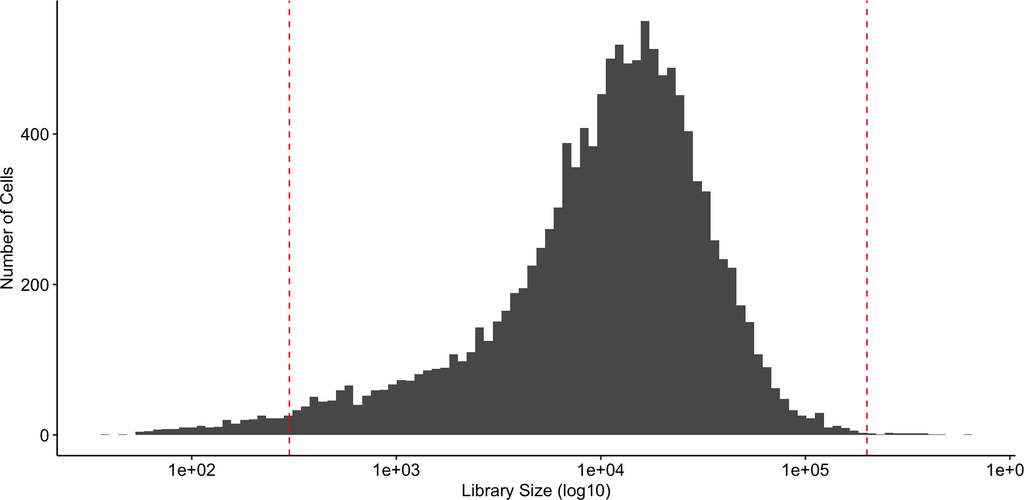

```r
lib_size_hist_log <- metadata_df  %>%
  ggplot(aes_string("nCount_ATAC")) +
  geom_histogram(bins = 100) +
  labs(x = "Library Size (log10)", y = "Number of Cells")+
  theme_pubr()+
  scale_x_log10() +
  geom_vline(xintercept = c(min_lib_size_atac,max_lib_size_atac), linetype = "dashed", color = "red")

lib_size_hist <- lib_size_hist_log +
    scale_x_continuous(limits = c(0, 5000)) +
    xlab("Library Size") +
    theme_pubr()

lib_size_hist_log
```

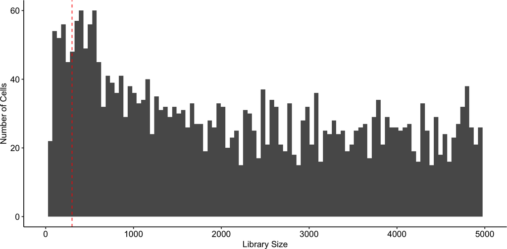

```r
lib_size_hist
```

### 6.6.2 Number of detected peaks

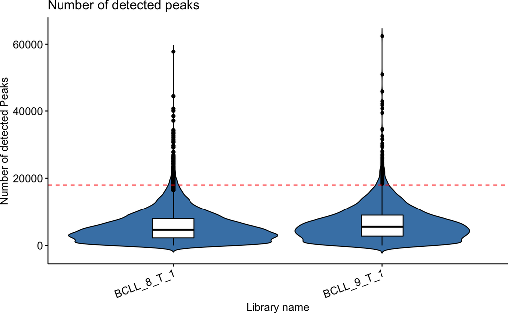

```r
ggviolin(
metadata_df,
  x="id",
  y="nFeature_ATAC",
  fill="steelblue",
  add="boxplot",
  title = "Number of detected peaks",
  ggtheme = theme_pubr(x.text.angle = 20),
  add.params = list(fill = "white"))+
  geom_hline(yintercept = 18000, linetype='dashed', col = 'red')+
  labs(x = "Library name", y = "Number of detected Peaks")
```

- The median number of peaks is: 5022
- The mean number of peaks is: 6068.17

**The median number of peaks per library**

```r
aggregate(nFeature_ATAC ~ id, data = metadata_df, median)
```

```
##           id nFeature_ATAC
## 1 BCLL_8_T_1          4656
## 2 BCLL_9_T_1          5552
```

### 6.6.3 Nucleosome Banding pattern

Nucleosome banding pattern: The histogram of DNA fragment sizes (determined from the paired-end sequencing reads) should exhibit a strong nucleosome banding pattern corresponding to the length of DNA wrapped around a single nucleosome. We calculate this per single cell, and quantify the approximate ratio of Di-nucleosomal(DI) and mono-nucleosomal(MONO) to nucleosome-free(NFR) fragments.

Single Cell ATAC read pairs produce detailed information about nucleosome packing and positioning. The fragment length distribution captures the nucleosome positioning periodicity.

The plot can be used to evaluate the quality of transposase reaction. We expect to find half or more of the of fragments within the nucleosome free regions (NFR) to confirm that our data is high quality and the transposase worked properly.

**Biobliography information about the minimum and maximum thresolds.** Nucleosome signal. The length of DNA wrapped around a single nucleosome has been experimentally determined as 147 bp. As Tn5 has a strong preference to integrate into nucleosome-free DNA, successful ATAC-seq experiments typically exhibit a depletion of DNA fragments with lengths that are multiples of 147 bp. We defined the nucleosome signal QC metric in Signac as the ratio of mononucleosomal (147–294 bp) to nucleosome-free (<147 bp) fragments sequenced for the cell, as a way of quantifying the expected depletion of nucleosome-length DNA fragments.

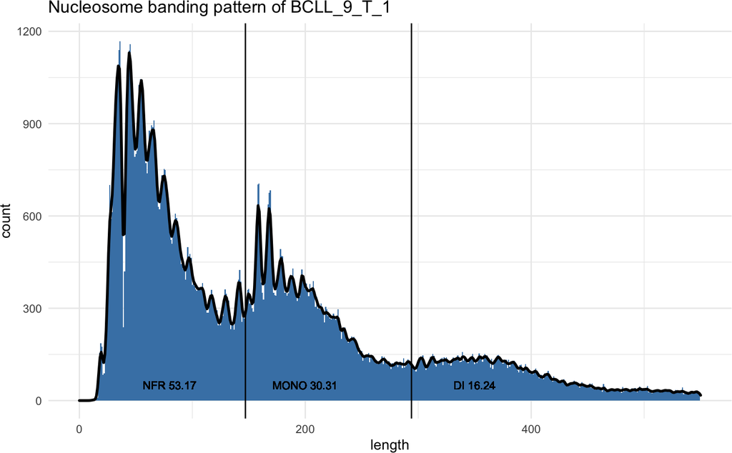

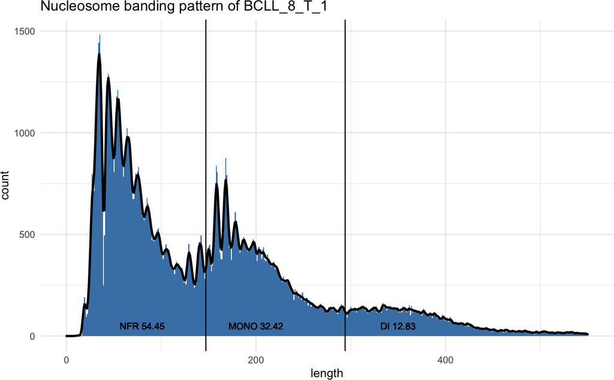

```r
nucleosome.bp <- function(seurat_object_df) {

  for (i in seq_along(seurat_object_df)){

  DefaultAssay(seurat_object_df[[i]]) <- "ATAC"
  fh <- FragmentHistogram(object = seurat_object_df[[i]])


  min.threshold<-147
  max.threshold<-294


  NFR<- (length(which(fh$data$length < min.threshold))/ nrow(fh$data)) *100
  MonoNR<- (length(which(fh$data$length > min.threshold &fh$data$length < max.threshold ))/ nrow(fh$data)) *100
  DiNR<- (length(which(fh$data$length > max.threshold))/ nrow(fh$data)) *100


  p <- ggplot(fh$data, aes(length)) +
    ggtitle(paste0("Nucleosome banding pattern of ",unique(names(seurat_object_df[i])))) +
    geom_histogram(binwidth = 1, fill = "steelblue") +
    geom_density(aes(y = ..count..), bw = 1, alpha = 0, col = "black", lwd = 1) + scale_x_continuous(limits = c(0, 550)) +
    geom_vline(xintercept = c(min.threshold, max.threshold)) +
    theme_minimal()+
    geom_text(x = 80, y = 50, label = paste("NFR",round(NFR, 2)), size = 3) +
    geom_text(x = 200, y = 50, label = paste("MONO",round(MonoNR, 2)), size = 3) +
    geom_text(x = 350, y = 50, label = paste("DI",round(DiNR, 2)), size = 3)


  print(p)
}
}

t<-nucleosome.bp(quality_control)
```

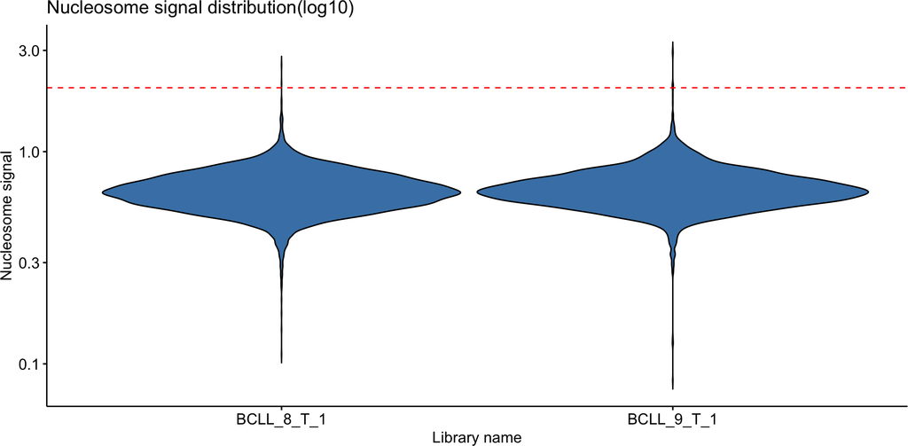

```r
ns <- ggviolin(metadata_df,
  x = "id", fill = "steelblue", x.text.angle = 0,
  y = "nucleosome_signal",
  title = "Nucleosome signal distribution(log10)",
) + scale_y_log10() + geom_hline(yintercept = nucleosome_signal_atac, linetype='dashed', col = 'red')
ns + labs(x = "Library name", y = "Nucleosome signal")
```

### 6.6.4 TSS enrichment

Transcriptional start site (TSS) enrichment score. The ENCODE project has defined an ATAC-seq targeting score based on the ratio of fragments centered at the TSS to fragments in TSS-flanking regions. Poor ATAC-seq experiments typically will have a low TSS enrichment score.

TSS scores = the depth of TSS (each 100bp window within 1000 bp each side) / the depth of end flanks (100bp each end).

TSSE score = max(mean(TSS score in each window))

To plot TSS enrichment profiles, we use the `TSSPlot()` function. TSS enrichment profiles show a clear peak in the center and a smaller shoulder peak at the downstream of the TSS (TSS + 220) could be the spacing region between two flanking nucleosomes. Two vertical back dashed lines are given at the consensus TSS (hg38 genome) and at TSS + 220 bp.

- `TSSPlot()` function: we use `tss.level` column in the metada.

We can see clearly that the reads concentrate around the TSS, with a prominent peak a bit upstream

```r
tss.enrich.plot <- function(seurat_object_df) {

  for (i in seq_along(seurat_object_df)){

  DefaultAssay(seurat_object_df[[i]]) <- "ATAC"
  fh <- FragmentHistogram(object = seurat_object_df[[i]])


  p <- TSSPlot(seurat_object_df[[i]], group.by = 'tss.level') +
    ggtitle(paste0("TSS enrichment score of ",unique(names(seurat_object_df[i])))) +
    theme_minimal() +
    geom_vline(xintercept =c(0,220),linetype = "dashed", colour = "black") +
    xlab(bquote('Relative Position (bp form TSS')) +
  ylab(expression("Relative enrichement"))

  print(p)
}
}
```

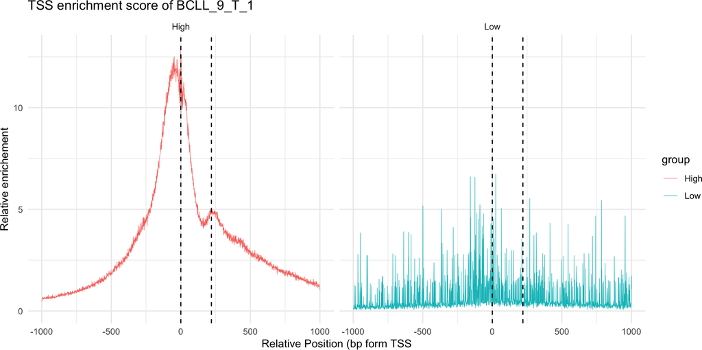

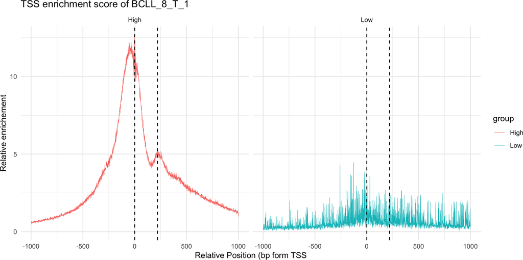

```r
tss<-tss.enrich.plot(quality_control)
```

Now, we are going to show the distribution of the TSS scores for each samples. Red dashes line represents the cut off used to slip the data by low and high TSS score.

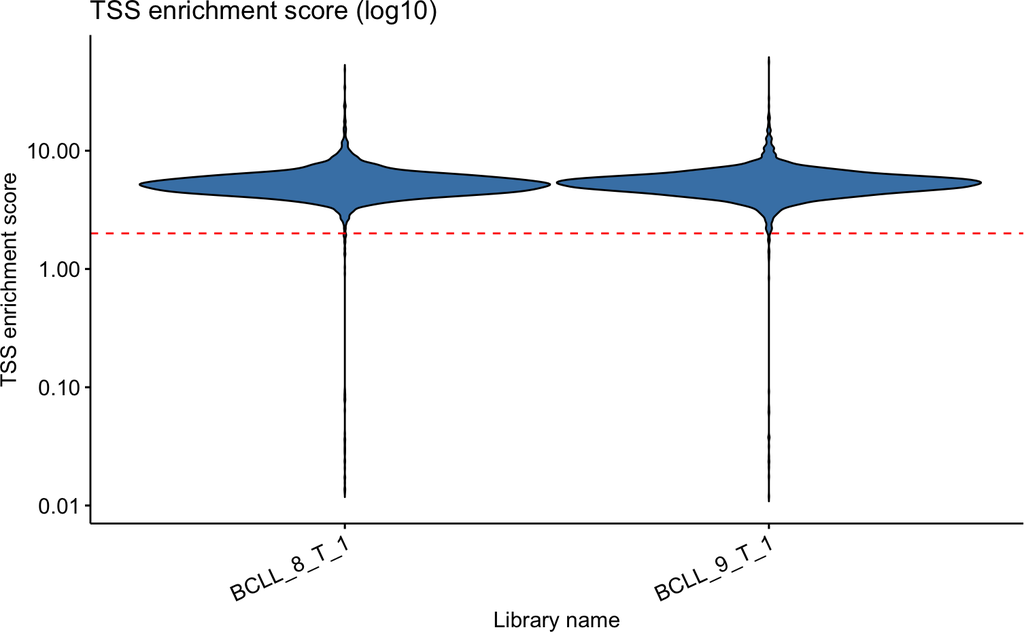

```r
ls<- ggviolin(metadata_df,
              x = "id", fill = "steelblue", x.text.angle = 25,y = "TSS.enrichment")  +
  geom_hline(yintercept = 2, linetype='dashed', col = 'red')+
  labs(x = "Library name", y = "TSS enrichment score")

ls + scale_y_log10()+ ggtitle("TSS enrichment score (log10)")
```

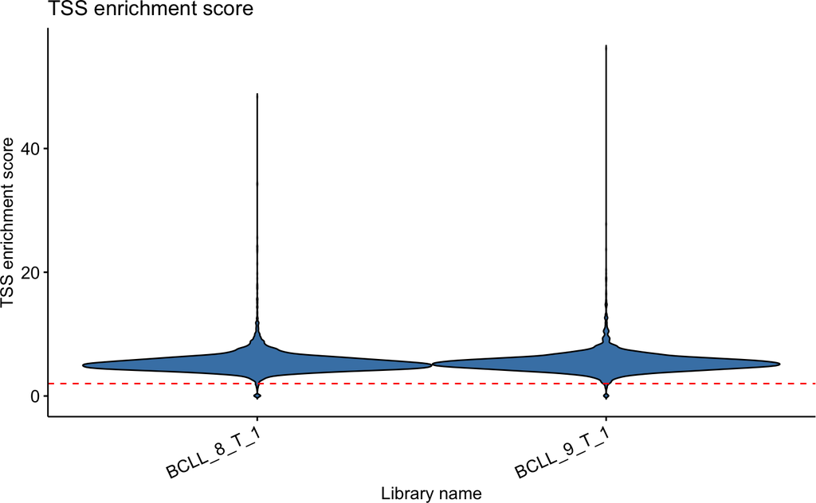

```r
ls + ggtitle("TSS enrichment score")
```

# 7 Filtering

## 7.1 Filtering Function

Once we set all the quality control metric we will use the `filtering.cell`function to filter out all the cell that are outliers for these QC metrics. This fucntion will return a seurat Object with only the cell that pass the metrics.

```r
filtering.cell <- function(seurat_object.list){

  seurat_object <- subset(x = seurat_object.list,
              subset = nCount_ATAC < max_lib_size_atac &
              nCount_RNA < max_lib_size_rna &
              nCount_ATAC > min_lib_size_atac &
              nCount_RNA > min_lib_size_rna &
              nFeature_RNA > min_ngenes_rna &
              TSS.enrichment > TSS_enrichment &
              nucleosome_signal < nucleosome_signal_atac &
              percent_mt < max_percent_mit
              )

  return(seurat_object)

}
```

## 7.2 Filtering step

Using the `lapply` we will perform the filtering step in all the samples saves in the `quality_control` list of Seurat Objects. The filtered new list of Seurat Object will be called `filtered.data`.

```r
filtered.data<- lapply(quality_control, filtering.cell)
```

```r
# data frame of the filtered cells samples
filtered.cell.df<-lapply(filtered.data, make.metadata.df)
filtered.cell.df <- map_df(filtered.cell.df, ~as.data.frame(.x), .id="id")
filtered.cell.df<-filtered.cell.df[order(filtered.cell.df$id),]
```

**Data frame of the number of cell with the metrics.**

```r
# dataframe with number of filtered cells
num_fil_cell<- as.data.frame(ddply(filtered.cell.df, .(id), nrow))

#change column names
colnames(num_fil_cell) <- c("library_name","filt_cells")
```

**Merge the initial number of cell, the filtered cell and the filtered out cells data frames**

```r
ini_filt_df<-merge(num_cell, num_fil_cell,by = "library_name")
```

**Difference between initial number of cell and filtered number of cell**

```r
#create a column with the number of deleted cells which should be the same than the filtered out cell.
ini_filt_df$del_cells <- (ini_filt_df$initial_cells - ini_filt_df$filt_cells)
```

**Percentages of the deleted and QC pass-filter cells**

```r
ini_filt_df$pct_keep_cells <-  round(((ini_filt_df$filt_cells/ini_filt_df$initial_cells)*100),2)
ini_filt_df$pct_del_cells <-  round((100-ini_filt_df$pct_keep_cells),2)
```

**Meaning of each column:**

- `pct_del_cells`= percentage of deleted cells
- `pct_keep_cells`= percentage of keep cells
- `initial_cells`= total number of initial cells
- `filt_cells`= total number of filtered cells
- `del_cell`= total number of deleted cells

Table 2: Table of total number of initial, filtered and filtered cell and the porcentaje of deleted and non-deleted cells of library

| library_name | Total Number initial_cells | Total Number filt_cells | Total Number del_cells | Percentage % pct_keep_cells | Percentage % pct_del_cells |
| --- | --- | --- | --- | --- | --- |
| BCLL_8_T_1 | 7181 | 6883 | 298 | 95.85 | 4.15 |
| BCLL_9_T_1 | 5572 | 5071 | 501 | 91.01 | 8.99 |

Mean of percentage of cell that pass the QC metrics is: 93.43 %

We are deleting on average 6.57 % of bad quality cells.

# 8 Merging Seurat Objects.

```r
atac_default_assay <- function(seurat_object){
  DefaultAssay(seurat_object) <- "ATAC"
  return(seurat_object)
}

remove_atac_assay <- function(seurat_object){
  DefaultAssay(seurat_object) <- "peaks"
  seurat_object@assays[["ATAC"]] <- NULL

  seurat_object<-RenameAssays(object = seurat_object, peaks = 'ATAC')
  return(seurat_object)
}


remove_peak_assay<- function(seurat_object){
  DefaultAssay(seurat_object) <- "RNA"
  seurat_object@assays[["peaks"]] <- NULL
  return(seurat_object)
}

remove_rna_assay<- function(seurat_object){

  seurat_object@assays[["RNA"]] <- NULL

  return(seurat_object)
}
```

## 8.1 Peak unify - ATAC

If peak calling is performed individually in each experiment, they may end up with regions of peaks that do not overlap perfectly. We can merge regions of peaks from all datasets to create a common set of peaks, and re-quantify each experiment separately using the merged common set of peaks. We can use several different methods to create a common set of peaks. Here we will directly use the `UnifyPeaks` function from the `Signac` package to extract the coordinates of the peaks from the list of seurat objects and reduce or disjoin the peaks to create a single non-overlapping set of peaks.

We will merge peaks from all the datasets to create a common peak set, and quantify this peak set in each experiment prior to merging the objects.

```r
# Create a unified set of peaks
filtered_data_peak <- lapply(filtered.data, atac_default_assay)
combined_peaks <- UnifyPeaks(object.list = filtered_data_peak, mode = "reduce")


#View the merged peaks set
combined_peaks
```

```
## GRanges object with 122489 ranges and 0 metadata columns:
##              seqnames          ranges strand
##                 <Rle>       <IRanges>  <Rle>
##        [1]       chr1     10134-10357      *
##        [2]       chr1   180768-181595      *
##        [3]       chr1   586037-586366      *
##        [4]       chr1   629712-630835      *
##        [5]       chr1   633787-634272      *
##        ...        ...             ...    ...
##   [122485] KI270728.1 1244133-1244535      *
##   [122486] KI270728.1 1755274-1755728      *
##   [122487] KI270728.1 1756618-1757019      *
##   [122488] KI270728.1 1791402-1791767      *
##   [122489] KI270734.1   117216-117326      *
##   -------
##   seqinfo: 35 sequences from an unspecified genome; no seqlengths
```

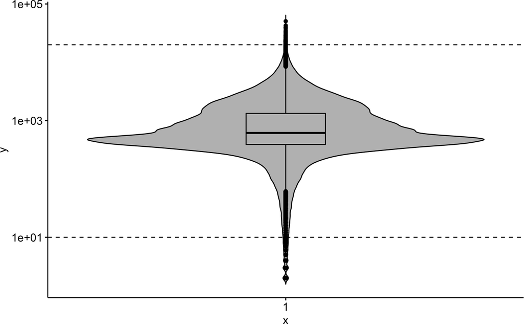

```r
# Keeping only standard chromosomes
combined_peaks <- keepStandardChromosomes(combined_peaks, pruning.mode = 'coarse')
peakwidths <- width(combined_peaks)

p<-ggviolin(peakwidths,add = "boxplot",fill = "gray") + scale_y_log10() +
  geom_hline(yintercept = c(10,20000), linetype='dashed', col = 'black')
p
```

```r
#Keeping only those peak between 10000 and 20 widths
combined_peaks <- combined_peaks[peakwidths < 20000 & peakwidths > 10]
combined_peaks
```

```
## GRanges object with 121094 ranges and 0 metadata columns:
##            seqnames            ranges strand
##               <Rle>         <IRanges>  <Rle>
##        [1]     chr1       10134-10357      *
##        [2]     chr1     180768-181595      *
##        [3]     chr1     586037-586366      *
##        [4]     chr1     629712-630835      *
##        [5]     chr1     633787-634272      *
##        ...      ...               ...    ...
##   [121090]     chrY 56830504-56834936      *
##   [121091]     chrY 56836180-56837356      *
##   [121092]     chrY 56838477-56838494      *
##   [121093]     chrY 56840466-56840548      *
##   [121094]     chrY 56842206-56842813      *
##   -------
##   seqinfo: 24 sequences from an unspecified genome; no seqlengths
```

## 8.2 Quantify peaks in each dataset

After obtaining the merged public peaks set, we can use the FeatureMatrix function to re-quantify the counts for each data set based on the common peaks set, and create a new assay to store the counted data.

**We don’t filter cells like in the tutorial, because we use already filtered matrices.**

The `peaks_quantification` function will re-quantify the counts for each data set by using `FeatureMatrix` function and it will create a new assay storing the Fragment object for each dataset.

```r
peaks_quantification <- function(seurat_filtered, peaks = combined_peaks){

  counts <- FeatureMatrix(
    fragments = Fragments(seurat_filtered),
    features = combined_peaks,
    cells = colnames(seurat_filtered))  #Vector of cells to include in this case we include all the cell in the Seurat object

  # create a new chromatin assay in the Seurat object with the new  matrix of peaks
  seurat_filtered[["peaks"]] <- CreateChromatinAssay(
    counts,
    genome = "hg38",
    fragments = Fragments(seurat_filtered),
    annotation = annotation)

  return(seurat_filtered)
}
```

```r
filtered_data_unified_peak <- lapply(filtered_data_peak, peaks_quantification)
```

## 8.3 Split objects Function

```r
#split seurat objects, creating object_# for each library
split_obj_function<- function(tonsil_filtered_RNA){
  for (i in seq_along(tonsil_filtered_RNA)){
                  object<-tonsil_filtered_RNA[[i]]
                 print(assign(paste("object",i,sep='_'), object, envir=.GlobalEnv))
  }
}
```

## 8.4 Merging RNA data

**Removing ATAC assay to reduce the size of the final Seurat object**

```r
filtered_data_unified_peak <- lapply(filtered_data_unified_peak, remove_atac_assay )
```

```
## Renaming default assay from peaks to ATAC
```

```
## Renaming default assay from peaks to ATAC
```

**Remove peak assays**

```r
filtered_data_unified_peak_rna <- lapply(filtered_data_unified_peak, remove_peak_assay )
```

```r
split_obj_function(filtered_data_unified_peak_rna)
```

```
## An object of class Seurat
## 157695 features across 5071 samples within 2 assays
## Active assay: RNA (36601 features, 0 variable features)
##  1 other assay present: ATAC
## An object of class Seurat
## 157695 features across 6883 samples within 2 assays
## Active assay: RNA (36601 features, 0 variable features)
##  1 other assay present: ATAC
```

```r
#Merging seurat objects

merged_rna <- merge(object_1, y = list(object_2),
                add.cell.ids = c(names(filtered_data_unified_peak_rna)))


rm(list=ls(pattern="object_"))
```

## 8.5 Merging ATAC

**Removing RNA assay to reduce the size of the final Seurat object**

```r
tonsil_unified_peaks_ATAC<- lapply(filtered_data_unified_peak, remove_rna_assay)
```

```r
split_obj_function(tonsil_unified_peaks_ATAC)
```

```
## An object of class Seurat
## 121094 features across 5071 samples within 1 assay
## Active assay: ATAC (121094 features, 0 variable features)
## An object of class Seurat
## 121094 features across 6883 samples within 1 assay
## Active assay: ATAC (121094 features, 0 variable features)
```

```r
#Merging seurat objects of ATAC assay in this case it is called  "peaks" assay

merged_ATAC <- merge(object_1, y = list(object_2),
                add.cell.ids = c(names(tonsil_unified_peaks_ATAC)))
rm(list=ls(pattern="object_"))
```

## 8.6 Merge RNA and ATAC assays

```r
merged_rna@assays$peaks<- merged_ATAC@assays$peaks

merged<-merged_rna
```

The `merged` object has 2 assay, RNA and ATAC assay in there assay

```r
merged@assays
```

```
## $RNA
## Assay data with 36601 features for 11954 cells
## First 10 features:
##  MIR1302-2HG, FAM138A, OR4F5, AL627309.1, AL627309.3, AL627309.2,
## AL627309.5, AL627309.4, AP006222.2, AL732372.1
##
## $ATAC
## ChromatinAssay data with 121094 features for 11954 cells
## Variable features: 0
## Genome: hg38
## Annotation present: TRUE
## Motifs present: FALSE
## Fragment files: 2
```

# 9 Save

```r
saveRDS(merged,paste0(path_to_save,"1.tonsil_filtered_merged_all.rds"))
```